# My first Rmd document

My name

Last update: 26 Nov 2018

After the header, you can just imput normal(ish) text.

- We can make lists by using hyphens
- then four spaces to add subitems
- like these

It’s possible to make the font *italic* or **bold** as well.

To change text colour inline, we need to use the HTML tag “span” .

# 1 It’s easy to add section headers

## 1.1 And subheaders as well

### 1.1.1 We can also make tabs

**With something different in each tab**

### 1.1.2 I’m another tab

*And this is my text!*

## 1.2 But that’s not all!

The really cool thing about Rmarkdown are code chunks. You are probably going to be writing those in R, but it is possible to use other languages as well. Code chunks let you embed the definition of figures / tables into your document, so if anything changes all you have to do is to `knit` it again, and all data will be updated.

Note that you can also add inline code. For example, this is a random number between 0 and 100: 73.4509228. And, if you had previously defined objects, in R, you can refer to them, too.

### 1.2.1 A simple plot

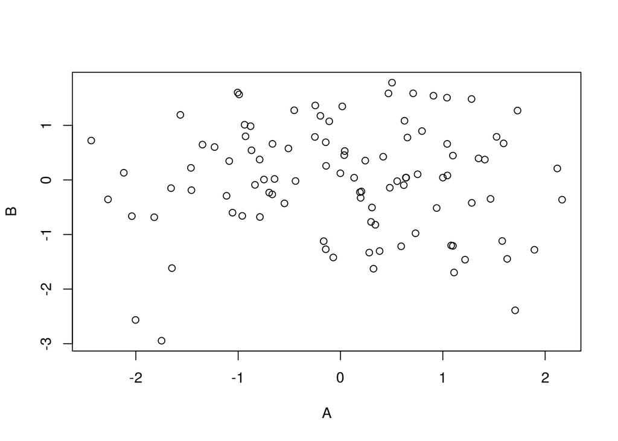

### 1.2.2 A ggplot example

#### 1.2.2.1 Single layer

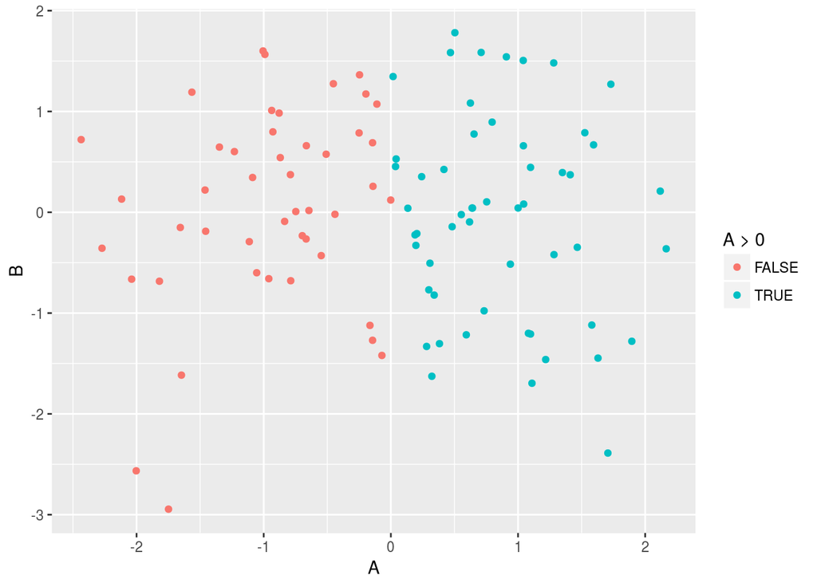

#### 1.2.2.2 More layers

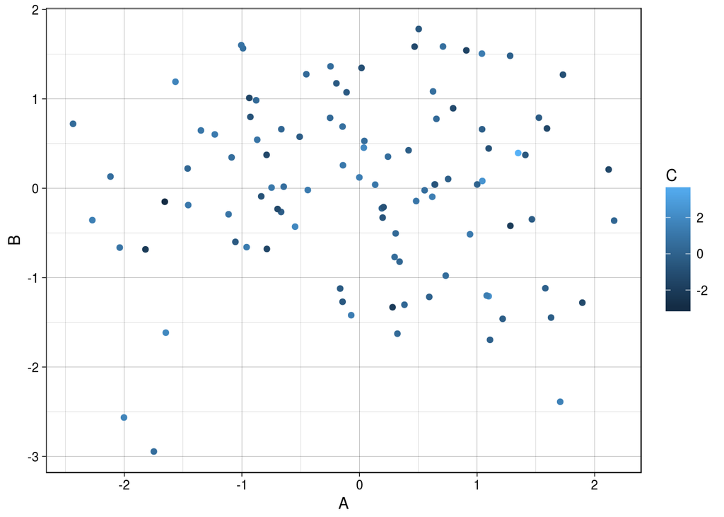